# Rmarkdown for dummies

(tutorial para aprender)

Javier Álvarez Liébana https://ucm.com (Universidad Complutense de Madrid)https://ucm.com  
2022-09-20

# R Markdown

El formato de escritura [Rmarkdown](https://rmarkdown.rstudio.com/), del paquete `rmarkdown`, nos permite:

- Escribir en `markdown`: lenguaje marcado que nos permite mezclar texto plano, algunos estilos como la **negrita** y la *cursiva*, `variables`.
- F�rmulas latex en línea como la media muestral $\overline{x} = \sum_{i=1}^{n} x_i f_i$, pero también entornos de ecuaciones

$$\overline{x} = \frac{\displaystyle \sum_{i=1}^{n} x_i}{n}$$

- Código `R`.

## Chunks

Cada archivo `.Rmd` contiene una cabecera (en formato `YAML`) para dar estilo y formato al documento, entre los separadores `---`. El código `R` lo meteremos en lo que llamaremos *chunks*: cajas de c�digo que al renderizar nuestro documento se ejecutarán.

```
[1] 4
```

También podemos ejecutarlo en l�nea pudiendo poner variables en el texto (`a + 3 =` 4). En los *chunks* de código podemos ponerles un nombre para luego mencionarlos y tendremos varias opciones:

- `include`: si está en `FALSE`, el código de dentro se ejecuta pero no es muestra en el informe (lo ejecutado sigue en memoria y puede ser usado más tarde).
- `echo`: si está en `FALSE` oculta el código pero no los resultados. Si está en `TRUE` muestra ambas.

```r
a <- 1
a + 3
```

```
[1] 4
```

- `message`: si está en `FALSE` oculta los mensajes generados por el código.
- `warning`: si está en `FALSE` oculta los warnings generados por `R`.

```r
# con warning = TRUE
sqrt(-1)
```

```
Warning in sqrt(-1): Se han producido NaNs
```

```
[1] NaN
```

```r
# con warning = FALSE
sqrt(-1)
```

```
[1] NaN
```

- `fig.cap`: añade un caption a las imágenes generadas

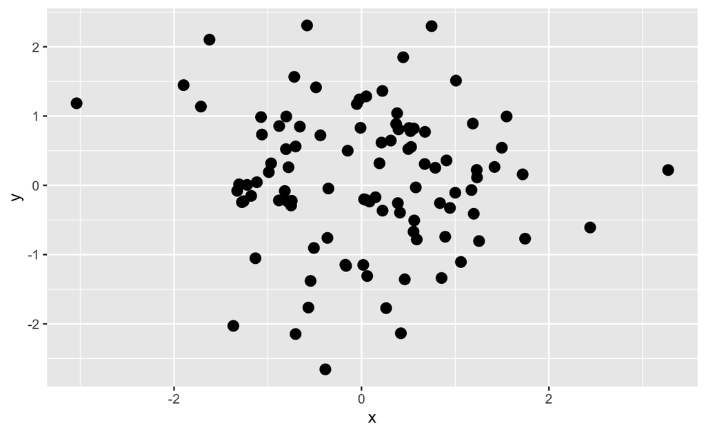

Figure 1: Ejemplo de gráfica

```r
library(tidyverse)
datos <- tibble("x" = rnorm(1e2), "y" = rnorm(1e2))
ggplot(datos) + geom_point(aes(x = x, y = y), size = 3)
```

[Documentación oficial](https://rmarkdown.rstudio.com/)